# R Notebook

# Re-running code from lab as a starting point

```r
# Clear Environment
rm(list=ls())

require(terra)
require(tidyterra)
require(sf)
require(adehabitatHR)
require(adehabitatLT)
require(adehabitatHS)
require(tidyverse)
require(survival)
#Import landcover tif
land = rast('https://github.com/ValenteJJ/SpatialEcology/raw/main/Week10/panther_landcover.tif')

#Reclassify the landcover tif
classification = read.table('https://raw.githubusercontent.com/ValenteJJ/SpatialEcology/main/Week10/landcover%20reclass.txt', header=T)
land = classify(land, classification[,c(1,3)])
land = categories(land, value=unique(classification[,c(3,4)]))


#Import panther locations
panthers = st_read('/vsicurl/https://github.com/ValenteJJ/SpatialEcology/raw/main/Week10/panthers.shp') %>%
  mutate(CatID = as.factor(CatID))
#Calculate wet forest focal statistic (5 km radius)
wetForest = land
values(wetForest) = 0
wetForest[land %in% c(10,12)] = 1
probMatrix = focalMat(wetForest, 5000, type='circle', fillNA=FALSE)
wetFocal = focal(wetForest, probMatrix, fun='sum', na.rm=T)


#Calculate dry forest focal statistic (5 km radius)
dryForest = land
values(dryForest) = 0
dryForest[land %in% c(11, 13)] = 1
probMatrix = focalMat(dryForest, 5000, type='circle', fillNA=FALSE)
dryFocal = focal(dryForest, probMatrix, fun='sum', na.rm=T)

#Stack together
layers = c(land, wetFocal, dryFocal)
names(layers) = c('landcover', 'wetForest', 'dryForest')

#Recreate our used points object
use = terra::extract(layers, panthers) %>%
  data.frame() %>%
  mutate(CatID = as.factor(panthers$CatID)) %>%
  group_by(CatID, landcover) %>%
  summarise(n = n()) %>%
  ungroup() %>%
  arrange(landcover) %>%
  pivot_wider(names_from = landcover, values_from = n, values_fill=0) %>%
  data.frame()
row.names(use) = use$CatID
use$CatID = NULL

#Recreate our available points object for a type II design
set.seed(8)
randII = spatSample(land, size=1000, as.points=T)
randIILand = data.frame(randII)

availII = randIILand %>%
  group_by(Description2) %>%
  summarise(n = n()) %>%
  ungroup() %>%
  rename(landcover = Description2) %>%
  filter(!(is.na(landcover) | landcover=='Exotics')) %>%
  pivot_wider(names_from = landcover, values_from = n)
```

# Challenge 1 (5 points)

In the lab, we estimated Manly’s statistic (wi) values for a type II study design. We also fit a logistic regression for a type II study design. For this challenge, you’re going to explore the relationship between wi values and beta values from a logistic regression model. Below I have recreated the analysis for producing wi values. I’ve also reconstructed the dataset we used for fitting the logistic regression models (allCovs).

Fit a new logistic regression model where use is a function of landcover-1 (the -1 removes the intercept from the fitted model). Make sure this is the only covariate in the model. Exponentiate the coefficients from the fitted model and compare them to the wi values calculated for each landcover type. What do you notice? Explain the similarities and/or differences in how you would interpret the wi values and exponentiated coefficients.

```r
#Recreating the wi analysis
selRatioII = widesII(u = use,
                     a = as.vector(as.matrix(availII)),
                     avknown = F,
                     alpha = 0.05)

#Recreating the dataset for logistic regression
useCovs = terra::extract(layers, panthers) %>%
  dplyr::select(-ID) %>%
  mutate(use=1)
backCovs = terra::extract(layers, randII) %>%
  dplyr::select(-ID) %>%
  mutate(use=0)
allCovs = rbind(useCovs, backCovs) %>%
  filter(!(is.na(landcover) | landcover=='Exotics')) %>%
  mutate(landcover = as.factor(as.character(landcover)))

# Logistic Regression

landcoverNames = sort(unique(allCovs$landcover))

rsfLandcover = glm(use ~ landcover-1, family=binomial(link=logit), data=allCovs)
expCoef = exp(rsfLandcover$coefficients)

print("Logistic Regression:")
```

```
## [1] "Logistic Regression:"
```

```r
expCoef
```

```
##           landcoverBarren   landcovercoastalwetland         landcoverCropland
##                1.57142857                0.14583333                0.34831461
##     landcoverCypressSwamp       landcoverDryprairie  landcoverFreshwatermarsh
##                5.00000000                1.12820513                0.79850746
##    landcoverHardwoodSwamp        landcoverOpenWater landcoverPastureGrassland
##                3.43750000                0.10236220                0.58227848
##         landcoverPineland      landcoverScrub/Shrub     landcoverUplandForest
##                2.67441860                1.16000000                2.86666667
##            landcoverUrban
##                0.07692308
```

```r
print("Manley Selection Measure:")
```

```
## [1] "Manley Selection Measure:"
```

```r
sort(selRatioII$wi)
```

```
##            Urban        OpenWater   coastalwetland         Cropland
##       0.08102276       0.10781769       0.15360566       0.36687836
## PastureGrassland  Freshwatermarsh       Dryprairie      Scrub.Shrub
##       0.61331156       0.84106466       1.18833387       1.22182328
##           Barren         Pineland     UplandForest    HardwoodSwamp
##       1.65517932       2.81695424       3.01944834       3.62070477
##     CypressSwamp
##       5.26647966
```

**Challenge 1 Answer:**

The logistic regression performs a similar task, and produces similar results, but the interpretation would be slightly different. The MSM of 5 would indicate that a Panther is using a habitat 5 times more than it’s availability, and the LR would indicate that points are 5 times as likely to fall in that particular habitat for each one unit increase in that particular landcover.

More specifically, The Wi score for Cypress swamp was 5.266, indicating that panthers selected cypress swamp greater than 5x its availability on the landscape. The exponentiated coeficients of the logistic regression for cypress swamps indicates that there is a positive relationships between panther use and cypress swamp, and that for each 1 unit increase in cypress swamp, the odd that a use point was in cypress swamp was 5x as likely.

$\color{red}{\text{Nice work. +5}}$

# Challenge 2 (5 points)

In the lab, we used the distribution of step lengths and turning angles to help us devise potential steps each individual could have taken at each point in time. Instead of step lengths, build a histogram representing the distribution of step speeds in km/hr. When and why might you choose to sample from a distribution of step speeds to calculate potential step lengths rather than drawing from the distribution of step lengths itself?

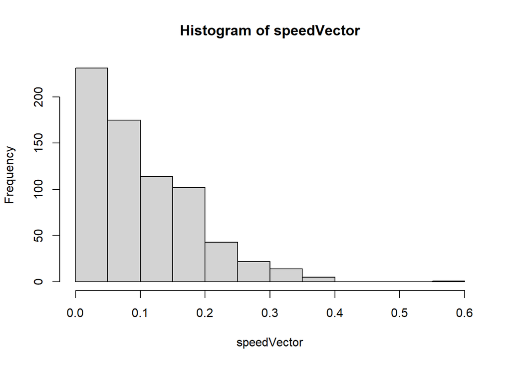

```r
# This function helps us tease out the date from the recorded DOY
substrRight = function(x, n){
  substr(x, nchar(x) - n+1, nchar(x))
}

#Here we're just creating a spatial object from our panthers sf object. Most of the code is dedicated to converting the DOY information to a real date.
panthersSp = panthers %>%
  mutate(CID = CatID) %>%
  mutate(Juldate = as.character(Juldate)) %>%
  mutate(date = as.numeric(substrRight(Juldate, 3))) %>%
  mutate(Date = as.Date(date, origin=as.Date("2006-01-01"))) %>%
  mutate(Date = as.POSIXct(Date, "%Y-%m-%d", tz='')) %>%
  as('Spatial')

#And this creates a trajectory object from the x-y coordinates and associated timestamps.
pantherLtraj = as.ltraj(xy=coordinates(panthersSp), date=panthersSp$Date, id=panthersSp$CatID, typeII=T)

# Speed = distance/time

speedVector = c()

for(i in 1:length(pantherLtraj))
{
  for(j in 1:nrow(pantherLtraj[[i]]))
  {
      MperSec = pantherLtraj[[i]]$dist[j]/pantherLtraj[[i]]$dt[j]
      # Meters per minute to km per hour
      KmperHr = MperSec*(3600/1000)
      speedVector = append(speedVector,KmperHr)
  }

}

hist(speedVector)
```

**Challenge 2 Answer:**

The most obvious scenario where it would be more appropriate to use the distribution of speeds rather than the distribution of step lengths would be when the time between location fixes was variable. With irregular sampling, the distribution of steps would be influenced by the duration of time between fixes, standardizing the measurement to a movement rate would correct this issue.

$\color{red}{\text{Excellent. +5}}$